# Bloque 2

Septiembre, 2017

## Temas

- Otros marcos para evaluación
- Objetivos generales de RM en México
- Indicadores
- Alinear objetivos con indicadores

## Marcos para evaluar reservas

## Trabajos anteriores

[figure not shown]

[figure not shown]

## IUCN

- Lista de indicadores biofísicos y sociales
- Buenos ejemplos y casos de estudio
- Breves indicaciones de cómo recopilar información
- No indica cómo evaluar indicadores

## Mascia et al. (2017)

- Aproximación 3FIGS (*"Three-framework approach for impact evaluation of governance in social–ecological systems"*):
  - Teoría de sistemas socio-ecológicos (Ostrom 2009)
  - Evaluación de impacto
  - Teoría de gobernanza de recursos de uso común

## Estos marcos

- Buena fuente para obtener indicadores (pero no alínean objetivos - indicadores)
- Buenos para análisis a gran escala
- No hay herramienta:
  - Replicabilidad
  - Estandarización
  - Empoderamiento (*e.g.* ZRP)

## Objetivos

¿Por qué?

- Los indicadores deben de seleccionarse según los objetivos

## Objetivos identificados

Extraidos de DOF, ETJ, planes de manejo, NOM-049-SAG/PESC (2014)

1. Evitar la sobreexplotación
2. Conservar especies bajo régimen de protección especial
3. Mantener procesos biológicos
4. Incrementar la productividad pesquera en aguas adyacentes
5. Preservar la diversidad biológica y los ecosistemas
6. Recuperar especies sobreexplotadas
7. Recuperar especies de interés comercial

## Una comunidad costera

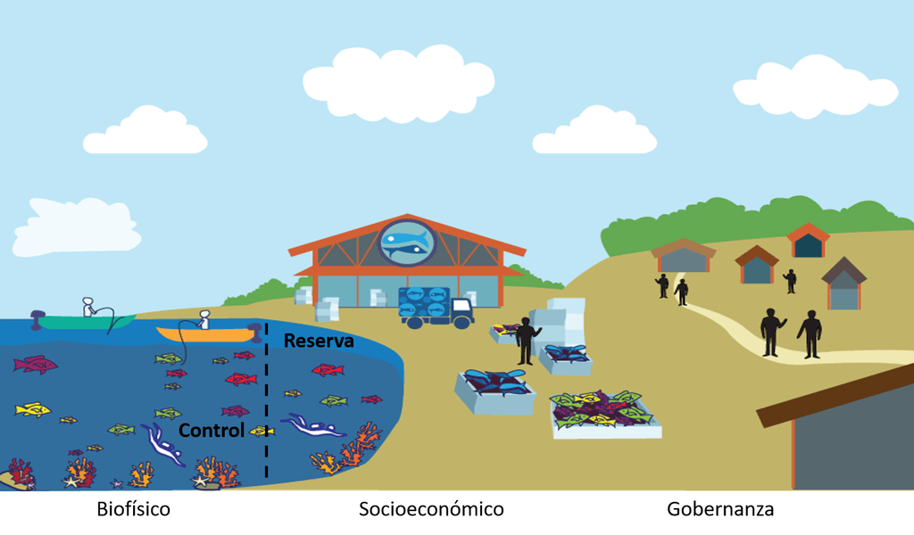

## Indicadores

## Indicadores

- Proceso de selección
  - Según los objetivos
  - Revisión de literatura
  - Disponibilidad de datos (**A**DCI)
  - Talleres
  - Comentarios de pescadores
- 3 categorías (B, S, G)
- Algunos indicadores
  - Responden a la reserva (*e.g.* Biomasa)
  - Influencían a la reserva **y** pueden cambiarse (*e.g.* Inspección y vigilancia)
  - Influencían a la reserva y **no** pueden cambiarse (*e.g.* Perturbación natural)
  - Indirectamente se relacionan con la reserva (*e.g.* Oportunidades económicas alternativas a la pesca)

## Biológicos

Se calculan antes y después de la implementación de la reserva para la reserva y control

- **B1** Índice de diversidad de Shannon
- **B2** Riqueza de especies
- **B3** Densidad de organismos potencialmente maduros*
- **B4** Densidad*
- **B5** Perturbación Natural
- **B6** Nivel Trófico Medio
- **B7** Biomasa*
  - *Aplica también a especies objetivo

## Socioeconómicos

- **S1** Arribos*
- **S2** Ingreso por arribos*
- **S3** Oportunidades económicas alternativas a la pesca
  - *Aplica también a especies objetivo

## Gobernanza

- **G1** Acceso a la pesquería
- **G2** Número de pescadores
- **G3** Reconocimiento legal de la reserva
- **G4** Tipo de reserva
- **G5** Grado de pesca ilegal
- **G6** Existencia de plan de manejo
- **G7** Inspección y vigilancia de la reserva
- **G8** Tamaño de la reserva
- **G9** Rzonamiento para la ubicación de la reserva
- **G10** Pertenencia a organizaciones pesqueras
- **G11** Tipo de organizaciones pesqueras
- **G12** Representación
- **G13** Regulaciones internas
- **G14** Efectividad percibida
- **G15** Impacto social de la reserva

## Objetivos e Indicadores

| Objetivo | B1 | B2 | B3 | B4 | B4* | B5 | B6 | B7 | B7* | S1 | S1* | S2 | S2* | S3 |
| --- | --- | --- | --- | --- | --- | --- | --- | --- | --- | --- | --- | --- | --- | --- |
| Evitar la sobreexplotación |  |  | x |  | x | x |  |  | x | x | x | x | x | x |
| Conservar especies bajo régimen de protección especial |  |  | x |  | x | x |  |  | x | x |  | x |  | x |
| Mantener procesos biológicos |  |  |  | x | x | x |  | x | x | x | x | x | x | x |
| Incrementar la productividad pesquera en aguas adyacentes |  |  | x | x | x | x | x | x | x | x | x | x | x | x |
| Preservar la diversidad biológica y los ecosistemas |  |  | x |  | x | x |  |  | x |  | x |  | x | x |
| Recuperar especies sobreexplotadas | x | x |  | x |  | x | x | x |  |  |  |  |  | x |
| Recuperar especies de interés comercial | x | x |  | x |  | x | x | x |  |  |  |  |  | x |

- Todos los de gobernanza se sugieren siempre

## Cálculo de los indicadores

- MAREA realiza los cálculos
  - Sólo hay que ingresar datos crudos (formato en siguiente bloque)
- Biológicos por transecto
- Socioeconómicos por año

## ¿Qué otros indicadores?

## Referencias

Mascia, Michael B, Helen E Fox, Louise Glew, Gabby N Ahmadia, Arun Agrawal, Megan Barnes, Xavier Basurto, et al. 2017. “A Novel Framework for Analyzing Conservation Impacts: Evaluation, Theory, and Marine Protected Areas.” *Ann N Y Acad Sci* 1399 (1): 93–115. doi:10.1111/nyas.13428.

NOM-049-SAG/PESC. 2014. “NORMA Oficial Mexicana Nom-049-Sag/Pesc-2014, Que Determina El Procedimiento Para Establecer Zonas de Refugio Para Los Recursos Pesqueros En Aguas de Jurisdicción Federal de Los Estados Unidos Mexicanos.” *DOF*.

Ostrom, Elinor. 2009. “A General Framework for Analyzing Sustainability of Social-Ecological Systems.” *Science* 325 (5939): 419–22. doi:10.1126/science.1172133.

Pomeroy, Robert S., Lani M. Watson, John E. Parks, and Gonzalo A. Cid. 2005. “How Is Your Mpa Doing? A Methodology for Evaluating the Management Effectiveness of Marine Protected Areas.” *Ocean Coast Manag* 48 (7-8): 485–502. doi:10.1016/j.ocecoaman.2005.05.004.

## Bloque 3